# Project: Investigate TMDB Movies Dataset

- Introduction
- Data Wrangling
- Exploratory Data Analysis
- Conclusions

## Introduction

> TMDB Movies dataset consists of number of movies with different information about each of them. Here we are investigating what affects revenues and whether they generate profits. Also, we check what makes a movie popular with audience. we wil go through the analysis with the following questions:

```python
import pandas as pd
import numpy as np
import matplotlib.pyplot as plt
% matplotlib inline
```

## Data Wrangling

Here we are assessing the dataset to make it cleaner and more organized.

### General Properties

```python
df = pd.read_csv('tmdb-movies.csv', index_col="id")
df.head()
```

| id | imdb_id | popularity | budget | revenue | original_title | cast | homepage | director | tagline | keywords | overview | runtime | genres | production_companies | release_date | vote_count | vote_average | release_year | budget_adj | revenue_adj |
| --- | --- | --- | --- | --- | --- | --- | --- | --- | --- | --- | --- | --- | --- | --- | --- | --- | --- | --- | --- | --- |
| 135397 | tt0369610 | 32.985763 | 150000000 | 1513528810 | Jurassic World | Chris Pratt\|Bryce Dallas Howard\|Irrfan Khan\|Vi... | http://www.jurassicworld.com/ | Colin Trevorrow | The park is open. | monster\|dna\|tyrannosaurus rex\|velociraptor\|island | Twenty-two years after the events of Jurassic ... | 124 | Action\|Adventure\|Science Fiction\|Thriller | Universal Studios\|Amblin Entertainment\|Legenda... | 6/9/15 | 5562 | 6.5 | 2015 | 1.379999e+08 | 1.392446e+09 |
| 76341 | tt1392190 | 28.419936 | 150000000 | 378436354 | Mad Max: Fury Road | Tom Hardy\|Charlize Theron\|Hugh Keays-Byrne\|Nic... | http://www.madmaxmovie.com/ | George Miller | What a Lovely Day. | future\|chase\|post-apocalyptic\|dystopia\|australia | An apocalyptic story set in the furthest reach... | 120 | Action\|Adventure\|Science Fiction\|Thriller | Village Roadshow Pictures\|Kennedy Miller Produ... | 5/13/15 | 6185 | 7.1 | 2015 | 1.379999e+08 | 3.481613e+08 |
| 262500 | tt2908446 | 13.112507 | 110000000 | 295238201 | Insurgent | Shailene Woodley\|Theo James\|Kate Winslet\|Ansel... | http://www.thedivergentseries.movie/#insurgent | Robert Schwentke | One Choice Can Destroy You | based on novel\|revolution\|dystopia\|sequel\|dyst... | Beatrice Prior must confront her inner demons ... | 119 | Adventure\|Science Fiction\|Thriller | Summit Entertainment\|Mandeville Films\|Red Wago... | 3/18/15 | 2480 | 6.3 | 2015 | 1.012000e+08 | 2.716190e+08 |
| 140607 | tt2488496 | 11.173104 | 200000000 | 2068178225 | Star Wars: The Force Awakens | Harrison Ford\|Mark Hamill\|Carrie Fisher\|Adam D... | http://www.starwars.com/films/star-wars-episod... | J.J. Abrams | Every generation has a story. | android\|spaceship\|jedi\|space opera\|3d | Thirty years after defeating the Galactic Empi... | 136 | Action\|Adventure\|Science Fiction\|Fantasy | Lucasfilm\|Truenorth Productions\|Bad Robot | 12/15/15 | 5292 | 7.5 | 2015 | 1.839999e+08 | 1.902723e+09 |
| 168259 | tt2820852 | 9.335014 | 190000000 | 1506249360 | Furious 7 | Vin Diesel\|Paul Walker\|Jason Statham\|Michelle ... | http://www.furious7.com/ | James Wan | Vengeance Hits Home | car race\|speed\|revenge\|suspense\|car | Deckard Shaw seeks revenge against Dominic Tor... | 137 | Action\|Crime\|Thriller | Universal Pictures\|Original Film\|Media Rights ... | 4/1/15 | 2947 | 7.3 | 2015 | 1.747999e+08 | 1.385749e+09 |

```python
df.shape
```

```
(10866, 20)
```

```python
df.describe()
```

|  | popularity | budget | revenue | runtime | vote_count | vote_average | release_year | budget_adj | revenue_adj |
| --- | --- | --- | --- | --- | --- | --- | --- | --- | --- |
| count | 10866.000000 | 1.086600e+04 | 1.086600e+04 | 10866.000000 | 10866.000000 | 10866.000000 | 10866.000000 | 1.086600e+04 | 1.086600e+04 |
| mean | 0.646441 | 1.462570e+07 | 3.982332e+07 | 102.070863 | 217.389748 | 5.974922 | 2001.322658 | 1.755104e+07 | 5.136436e+07 |
| std | 1.000185 | 3.091321e+07 | 1.170035e+08 | 31.381405 | 575.619058 | 0.935142 | 12.812941 | 3.430616e+07 | 1.446325e+08 |
| min | 0.000065 | 0.000000e+00 | 0.000000e+00 | 0.000000 | 10.000000 | 1.500000 | 1960.000000 | 0.000000e+00 | 0.000000e+00 |
| 25% | 0.207583 | 0.000000e+00 | 0.000000e+00 | 90.000000 | 17.000000 | 5.400000 | 1995.000000 | 0.000000e+00 | 0.000000e+00 |
| 50% | 0.383856 | 0.000000e+00 | 0.000000e+00 | 99.000000 | 38.000000 | 6.000000 | 2006.000000 | 0.000000e+00 | 0.000000e+00 |
| 75% | 0.713817 | 1.500000e+07 | 2.400000e+07 | 111.000000 | 145.750000 | 6.600000 | 2011.000000 | 2.085325e+07 | 3.369710e+07 |
| max | 32.985763 | 4.250000e+08 | 2.781506e+09 | 900.000000 | 9767.000000 | 9.200000 | 2015.000000 | 4.250000e+08 | 2.827124e+09 |

```python
df.info()
```

```
<class 'pandas.core.frame.DataFrame'>
Int64Index: 10866 entries, 135397 to 22293
Data columns (total 20 columns):
imdb_id                 10856 non-null object
popularity              10866 non-null float64
budget                  10866 non-null int64
revenue                 10866 non-null int64
original_title          10866 non-null object
cast                    10790 non-null object
homepage                2936 non-null object
director                10822 non-null object
tagline                 8042 non-null object
keywords                9373 non-null object
overview                10862 non-null object
runtime                 10866 non-null int64
genres                  10843 non-null object
production_companies    9836 non-null object
release_date            10866 non-null object
vote_count              10866 non-null int64
vote_average            10866 non-null float64
release_year            10866 non-null int64
budget_adj              10866 non-null float64
revenue_adj             10866 non-null float64
dtypes: float64(4), int64(5), object(11)
memory usage: 1.7+ MB
```

### Data Cleaning

> After taking a look on the dataset, we perform some changes to make it easier to handle:

```python
# 1- Removing unnecessary columns:
df.drop(['homepage','tagline', 'overview', 'keywords', 'imdb_id','budget', 'revenue'], axis = 1, inplace = True)
```

```python
# 2- Changing 'release_date' type into date:
df['release_date'] = pd.to_datetime(df['release_date'])
df['release_date'].dtypes
```

```
dtype('<M8[ns]')
```

```python
# 3- Deleting duplicated values:
df.drop_duplicates(inplace= True)
sum(df.duplicated())
```

```
0
```

```python
# 4- Dealing with rows with insufficient data.
##[budget_adj, revenue_ad, runtime] have minimum values of 0 which is not logic, so we are replacing them with the mean.
### Define a function to convert 0 values to the median

def mean(col):
    col.replace({0: col.mean()}, inplace=True)
```

```python
mean(df['runtime'])
```

```python
mean(df['budget_adj'])
```

```python
mean(df['revenue_adj'])
```

```python
# Checking no min. values of zero
df.describe()
```

|  | popularity | runtime | vote_count | vote_average | release_year | budget_adj | revenue_adj |
| --- | --- | --- | --- | --- | --- | --- | --- |
| count | 10865.000000 | 10865.000000 | 10865.000000 | 10865.000000 | 10865.000000 | 1.086500e+04 | 1.086500e+04 |
| mean | 0.646446 | 102.363021 | 217.399632 | 5.975012 | 2001.321859 | 2.675046e+07 | 7.981225e+07 |
| std | 1.000231 | 30.904043 | 575.644627 | 0.935138 | 12.813260 | 3.051007e+07 | 1.365647e+08 |
| min | 0.000065 | 2.000000 | 10.000000 | 1.500000 | 1960.000000 | 9.210911e-01 | 2.370705e+00 |
| 25% | 0.207575 | 90.000000 | 17.000000 | 5.400000 | 1995.000000 | 1.754989e+07 | 5.136900e+07 |
| 50% | 0.383831 | 99.000000 | 38.000000 | 6.000000 | 2006.000000 | 1.754989e+07 | 5.136900e+07 |
| 75% | 0.713857 | 111.000000 | 146.000000 | 6.600000 | 2011.000000 | 2.085325e+07 | 5.136900e+07 |
| max | 32.985763 | 900.000000 | 9767.000000 | 9.200000 | 2015.000000 | 4.250000e+08 | 2.827124e+09 |

```python
## Eliminating unknown values:
df.dropna(inplace=True)
```

```python
df.info()
```

```
<class 'pandas.core.frame.DataFrame'>
Int64Index: 9772 entries, 135397 to 22293
Data columns (total 13 columns):
popularity              9772 non-null float64
original_title          9772 non-null object
cast                    9772 non-null object
director                9772 non-null object
runtime                 9772 non-null float64
genres                  9772 non-null object
production_companies    9772 non-null object
release_date            9772 non-null datetime64[ns]
vote_count              9772 non-null int64
vote_average            9772 non-null float64
release_year            9772 non-null int64
budget_adj              9772 non-null float64
revenue_adj             9772 non-null float64
dtypes: datetime64[ns](1), float64(5), int64(2), object(5)
memory usage: 1.0+ MB
```

```python
df.head()
```

| id | popularity | original_title | cast | director | runtime | genres | production_companies | release_date | vote_count | vote_average | release_year | budget_adj | revenue_adj |
| --- | --- | --- | --- | --- | --- | --- | --- | --- | --- | --- | --- | --- | --- |
| 135397 | 32.985763 | Jurassic World | Chris Pratt\|Bryce Dallas Howard\|Irrfan Khan\|Vi... | Colin Trevorrow | 124.0 | Action\|Adventure\|Science Fiction\|Thriller | Universal Studios\|Amblin Entertainment\|Legenda... | 2015-06-09 | 5562 | 6.5 | 2015 | 1.379999e+08 | 1.392446e+09 |
| 76341 | 28.419936 | Mad Max: Fury Road | Tom Hardy\|Charlize Theron\|Hugh Keays-Byrne\|Nic... | George Miller | 120.0 | Action\|Adventure\|Science Fiction\|Thriller | Village Roadshow Pictures\|Kennedy Miller Produ... | 2015-05-13 | 6185 | 7.1 | 2015 | 1.379999e+08 | 3.481613e+08 |
| 262500 | 13.112507 | Insurgent | Shailene Woodley\|Theo James\|Kate Winslet\|Ansel... | Robert Schwentke | 119.0 | Adventure\|Science Fiction\|Thriller | Summit Entertainment\|Mandeville Films\|Red Wago... | 2015-03-18 | 2480 | 6.3 | 2015 | 1.012000e+08 | 2.716190e+08 |
| 140607 | 11.173104 | Star Wars: The Force Awakens | Harrison Ford\|Mark Hamill\|Carrie Fisher\|Adam D... | J.J. Abrams | 136.0 | Action\|Adventure\|Science Fiction\|Fantasy | Lucasfilm\|Truenorth Productions\|Bad Robot | 2015-12-15 | 5292 | 7.5 | 2015 | 1.839999e+08 | 1.902723e+09 |
| 168259 | 9.335014 | Furious 7 | Vin Diesel\|Paul Walker\|Jason Statham\|Michelle ... | James Wan | 137.0 | Action\|Crime\|Thriller | Universal Pictures\|Original Film\|Media Rights ... | 2015-04-01 | 2947 | 7.3 | 2015 | 1.747999e+08 | 1.385749e+09 |

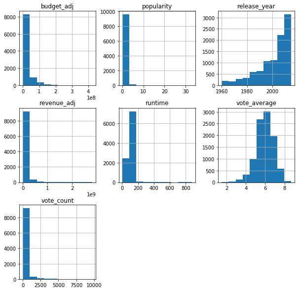

```python
df.hist(figsize=(10,10));
```

# Exploratory Data Analysis

This part holds the answers for the questions stated in the introduction.

# Q1: Who is the director with the highest generated revenues?

There are movies directed by two or more directors. So, we are going to get works of every director separately.

We take 'director' and 'revenue_adj' columns to make a new dataframe after splitting 'director' column.

```python
directors = df['director'].str.split("|", expand= True)
```

```python
directors = directors.stack()
directors = pd.DataFrame(directors)
```

```python
directors.head()
```

| id |  | 0 |
| --- | --- | --- |
| 135397 | 0 | Colin Trevorrow |
| 76341 | 0 | George Miller |
| 262500 | 0 | Robert Schwentke |
| 140607 | 0 | J.J. Abrams |
| 168259 | 0 | James Wan |

```python
directors.rename(columns={0: 'directors'}, inplace= True)
directors.head()
```

| id |  | directors |
| --- | --- | --- |
| 135397 | 0 | Colin Trevorrow |
| 76341 | 0 | George Miller |
| 262500 | 0 | Robert Schwentke |
| 140607 | 0 | J.J. Abrams |
| 168259 | 0 | James Wan |

Now, we merge 'directors' with the main dataframe 'df' and drop the original 'director' column.

```python
df_dir = df.merge(directors, left_index= True, right_index= True)
```

```python
df_dir.drop('director', axis= 1, inplace= True)
```

```python
df_dir.rename(columns={'directors': 'director'}, inplace= True)
```

```python
df_dir.head()
```

| id |  | popularity | original_title | cast | runtime | genres | production_companies | release_date | vote_count | vote_average | release_year | budget_adj | revenue_adj | director |
| --- | --- | --- | --- | --- | --- | --- | --- | --- | --- | --- | --- | --- | --- | --- |
| 135397 | 0 | 32.985763 | Jurassic World | Chris Pratt\|Bryce Dallas Howard\|Irrfan Khan\|Vi... | 124.0 | Action\|Adventure\|Science Fiction\|Thriller | Universal Studios\|Amblin Entertainment\|Legenda... | 2015-06-09 | 5562 | 6.5 | 2015 | 1.379999e+08 | 1.392446e+09 | Colin Trevorrow |
| 76341 | 0 | 28.419936 | Mad Max: Fury Road | Tom Hardy\|Charlize Theron\|Hugh Keays-Byrne\|Nic... | 120.0 | Action\|Adventure\|Science Fiction\|Thriller | Village Roadshow Pictures\|Kennedy Miller Produ... | 2015-05-13 | 6185 | 7.1 | 2015 | 1.379999e+08 | 3.481613e+08 | George Miller |
| 262500 | 0 | 13.112507 | Insurgent | Shailene Woodley\|Theo James\|Kate Winslet\|Ansel... | 119.0 | Adventure\|Science Fiction\|Thriller | Summit Entertainment\|Mandeville Films\|Red Wago... | 2015-03-18 | 2480 | 6.3 | 2015 | 1.012000e+08 | 2.716190e+08 | Robert Schwentke |
| 140607 | 0 | 11.173104 | Star Wars: The Force Awakens | Harrison Ford\|Mark Hamill\|Carrie Fisher\|Adam D... | 136.0 | Action\|Adventure\|Science Fiction\|Fantasy | Lucasfilm\|Truenorth Productions\|Bad Robot | 2015-12-15 | 5292 | 7.5 | 2015 | 1.839999e+08 | 1.902723e+09 | J.J. Abrams |
| 168259 | 0 | 9.335014 | Furious 7 | Vin Diesel\|Paul Walker\|Jason Statham\|Michelle ... | 137.0 | Action\|Crime\|Thriller | Universal Pictures\|Original Film\|Media Rights ... | 2015-04-01 | 2947 | 7.3 | 2015 | 1.747999e+08 | 1.385749e+09 | James Wan |

Here we get the hieghest 15 directors in terms of revenue.

```python
df_dir_max = df_dir.groupby('director').revenue_adj.sum().sort_values(ascending= False)
df_dir_max = df_dir_max[0:15]
```

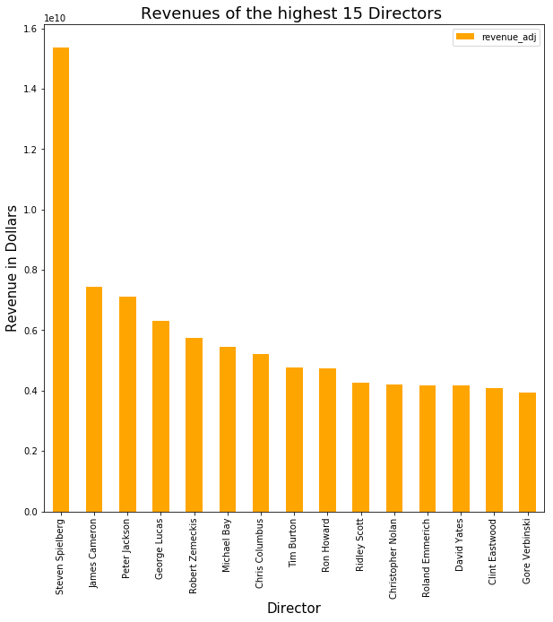

```python
df_dir_max.plot.bar(color='orange', figsize=(10,10))
plt.ylabel('Revenue in Dollars', fontsize= 15)
plt.xlabel('Director', fontsize= 15)
plt.title('Revenues of the highest 15 Directors', fontsize= 18)
plt.legend();
```

We see that the legendry Spielberg takes the lead against James cameron with almost the double value.

# Q2: Which genre is associated with highest revenues?

Just like the previous question, we are going to separate each genre with its revenues. First, we split 'genres' then make a new dataframe for genre. After tht we genre column name from 0 to genre

```python
genres = df['genres'].str.split("|", expand= True)
```

```python
genres = genres.stack()
genres = pd.DataFrame(genres)
```

```python
genres.head()
```

| id |  | 0 |
| --- | --- | --- |
| 135397 | 0 | Action |
|  | 1 | Adventure |
|  | 2 | Science Fiction |
|  | 3 | Thriller |
| 76341 | 0 | Action |

```python
genres.rename(columns={0: 'genre'}, inplace= True)
genres.head()
```

| id |  | genre |
| --- | --- | --- |
| 135397 | 0 | Action |
|  | 1 | Adventure |
|  | 2 | Science Fiction |
|  | 3 | Thriller |
| 76341 | 0 | Action |

Now, we merge 'genres' with the main dataframe 'df' and drop the original 'genres' column.

```python
df1 = df.merge(genres, left_index= True, right_index= True)
```

```python
df1.drop('genres', axis= 1, inplace= True)
```

```python
df1.head()
```

| id |  | popularity | original_title | cast | director | runtime | production_companies | release_date | vote_count | vote_average | release_year | budget_adj | revenue_adj | genre |
| --- | --- | --- | --- | --- | --- | --- | --- | --- | --- | --- | --- | --- | --- | --- |
| 135397 | 0 | 32.985763 | Jurassic World | Chris Pratt\|Bryce Dallas Howard\|Irrfan Khan\|Vi... | Colin Trevorrow | 124.0 | Universal Studios\|Amblin Entertainment\|Legenda... | 2015-06-09 | 5562 | 6.5 | 2015 | 1.379999e+08 | 1.392446e+09 | Action |
|  | 1 | 32.985763 | Jurassic World | Chris Pratt\|Bryce Dallas Howard\|Irrfan Khan\|Vi... | Colin Trevorrow | 124.0 | Universal Studios\|Amblin Entertainment\|Legenda... | 2015-06-09 | 5562 | 6.5 | 2015 | 1.379999e+08 | 1.392446e+09 | Adventure |
|  | 2 | 32.985763 | Jurassic World | Chris Pratt\|Bryce Dallas Howard\|Irrfan Khan\|Vi... | Colin Trevorrow | 124.0 | Universal Studios\|Amblin Entertainment\|Legenda... | 2015-06-09 | 5562 | 6.5 | 2015 | 1.379999e+08 | 1.392446e+09 | Science Fiction |
|  | 3 | 32.985763 | Jurassic World | Chris Pratt\|Bryce Dallas Howard\|Irrfan Khan\|Vi... | Colin Trevorrow | 124.0 | Universal Studios\|Amblin Entertainment\|Legenda... | 2015-06-09 | 5562 | 6.5 | 2015 | 1.379999e+08 | 1.392446e+09 | Thriller |
| 76341 | 0 | 28.419936 | Mad Max: Fury Road | Tom Hardy\|Charlize Theron\|Hugh Keays-Byrne\|Nic... | George Miller | 120.0 | Village Roadshow Pictures\|Kennedy Miller Produ... | 2015-05-13 | 6185 | 7.1 | 2015 | 1.379999e+08 | 3.481613e+08 | Action |

Finally, we plot the relation between Revenues and genres

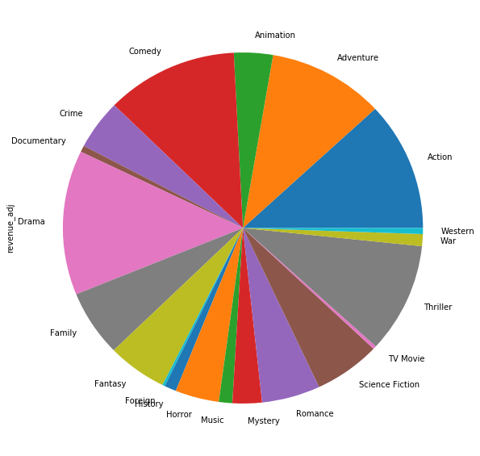

```python
df1.groupby('genre').revenue_adj.sum().plot.pie(figsize=(10,10));
```

For this dataset, Drama, Action, and comedy movies take the first 3 places as the highest revenues. Foreign and TV movies are the lowest.

# Q3: Do higher revenues mean higher profits?

To answer this question, we add a new column 'profit' equals the difference between 'revenue_adj' and 'budget_adj'

```python
df['profit'] = df['revenue_adj'] - df['budget_adj']
```

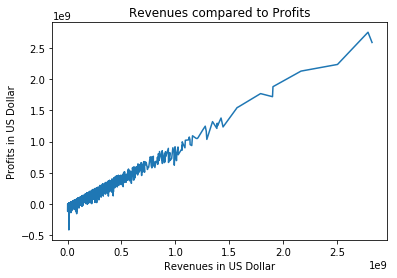

```python
df.groupby(['revenue_adj']).profit.mean().plot(kind='line')
plt.title("Revenues compared to Profits")
plt.xlabel("Revenues in US Dollar")
plt.ylabel("Profits in US Dollar");
```

Previous plot shows that increasing in revenues has a positive correlation with profits

## Q4: What is the most popular genre?

Here we use a chart comparing between different genres and its popularity.

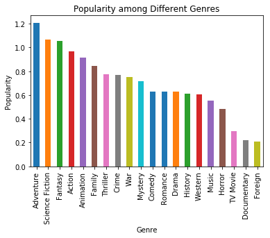

```python
df1.groupby(['genre']).popularity.mean().sort_values(ascending=False).plot(kind='bar')
plt.title("Popularity among Different Genres")
plt.xlabel("Genre")
plt.ylabel("Popularity");
```

This graph show that Adventure movies are the most popular genre followed by Science Fiction and Fantasy.

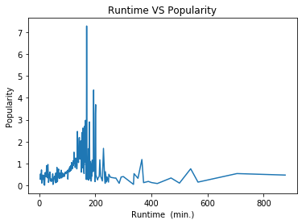

```python
df.groupby(['runtime']).popularity.mean().plot(kind='line')
plt.title("Runtime VS Popularity")
plt.xlabel("Runtime  (min.)")
plt.ylabel("Popularity");
```

Increasing runtime affects popularity positively (approximately up to 180 minutes) then the line goes down.

## Conclusions

> After going through this analysis process, starting by assessing and cleaning the dataset (removing unnecessary columns, elimnating unnecessary data and duplicate values). Also, we explored the dataset and reached the following results using statistics and graphs:

1- Steven Spielberg generated the highest revenues with almost 15 billion dolars.  
2- Drama movies have the highest revenues, and Foreign movies come last.  
3- Higher profits is associated with higher revenues.  
4- Most popular genres are Adventure, Science Fiction and Fantasy.  
5- Too short and too long movies don't gain much popularity among people.

## Limitations:

1- Assigning mean values instead of zeros for ('revenue_adj', 'budget_adj', 'runtime') columns may alter the results.  
2- Eliminating duplicates and unknown values costed us about 10% of the dataset which may cause a slight change in the conclusion .

```python
from subprocess import call
call(['python', '-m', 'nbconvert', 'Investigate_a_Dataset.ipynb'])
```

```
0
```